# Analyzing Individual BGG Users

Phil Henrickson

2022-01-02

# **Zabby’s** BoardGameGeek Collection

This notebook contains a set of analyses for the selected user’s boardgamegeek collection. The bulk of the analysis is focused on building a user-specific predictive model to predict the games that Zabby is likely to own. This enables to ask questions like, based on the games the user currently owns, what games are a good fit for their collection? What upcoming games are they likely to purchase?

This analysis is based on data from BoardGameGeek that was last updated on **2021-12-20.**

# 1 Collection Overview

We can look at a basic description of the number of games that the user owns, has rated, has previously owned, etc.

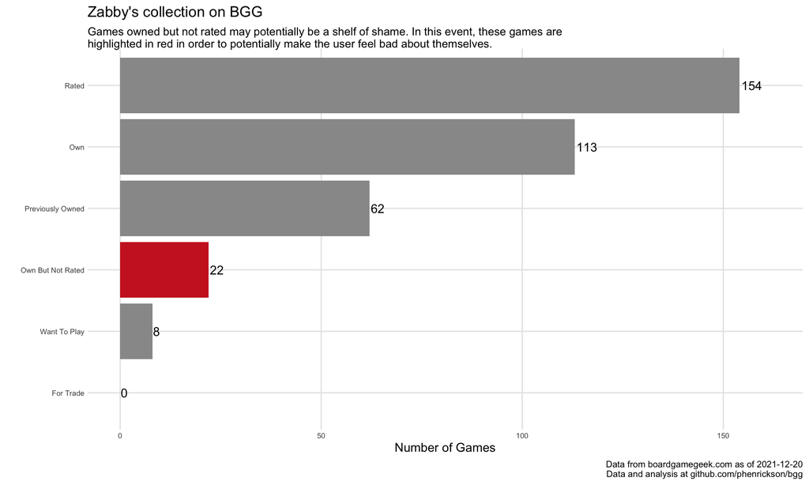

What years has the user owned/rated games from? While we can’t see when a user added or removed a game from their collection, we can look at their collection by the years in which their games were published.

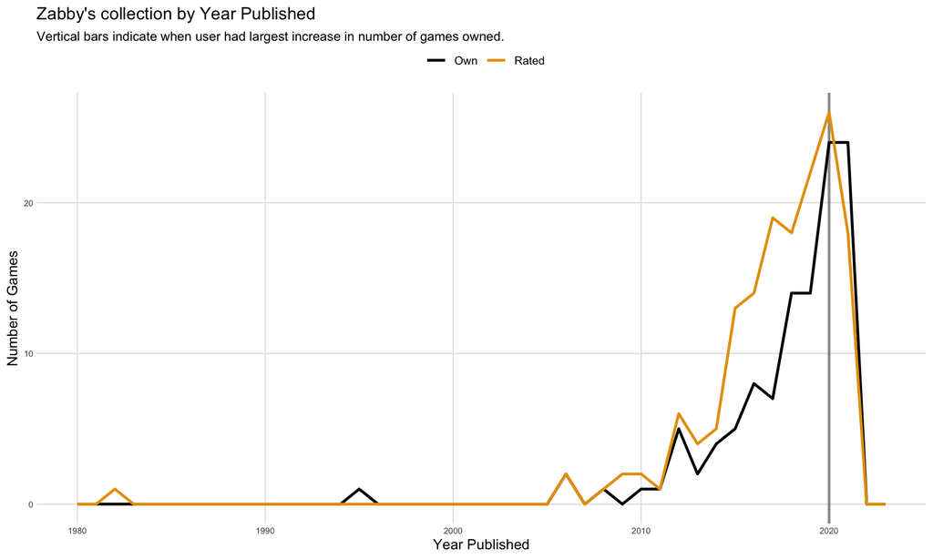

## 1.1 What types of games does Zabby own?

We can look at the most frequent types of categories, mechanics, designers, and artists that appear in a user’s collection.

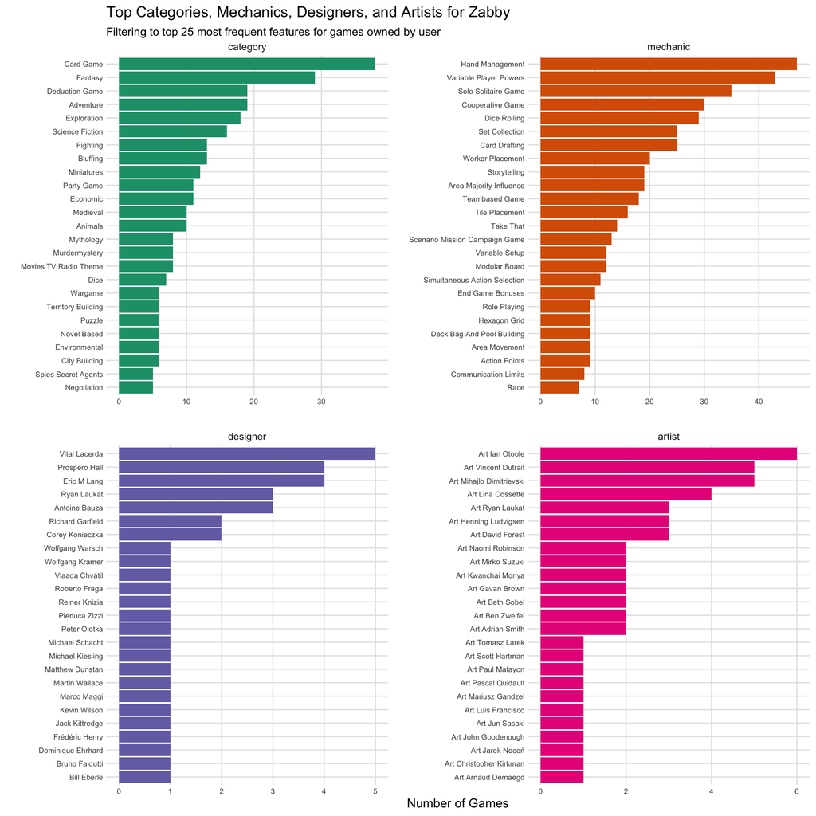

# 2 Modeling **Zabby’s** Collection

| username | dataset | period | games_owned | games_rated | games_played |
| --- | --- | --- | --- | --- | --- |
| Zabby | training | published before 2020 | 63 | 105 | 116 |
| Zabby | test | published 2020 or later | 48 | 44 | 60 |

There are two main (binary) outcomes we will be modeling for the user.

The first, **own** refers to whether the user currently lists a game as owned in their collection. The second, **played** refers to whether the user currently owns, has rated, or previously owned a game. This means the latter will generally have a larger list of games, but may still be a useful category to examine for people who play lots of games without necessarily owning them.

We will train predictive models to learn the probability that the user will own or play individual games based on their features.

## 2.1 Coefficients for Zabby

We can examine coefficients from the trained modes, which are penalized logistic regressions fit to our two main outcomes. Positive values indicate that a feature increases a user’s probabilility of owning/rating a game, while negative values indicate a feature decreases the probability.

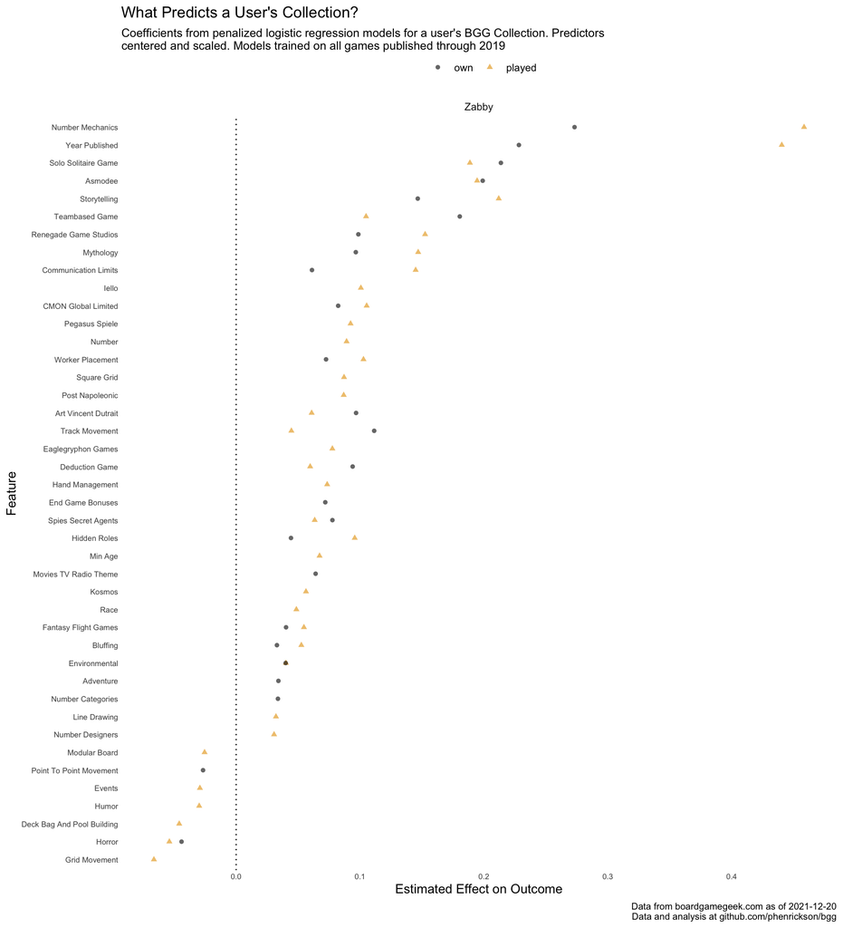

## 2.2 Visualizing Predictors for Zabby’s Collection

Why did the model identify these features? We can make density plots of the important features for predicting whether the user owned a game. Blue indicates the density for games owned by the user, while grey indicates the density for games not owned by the user.

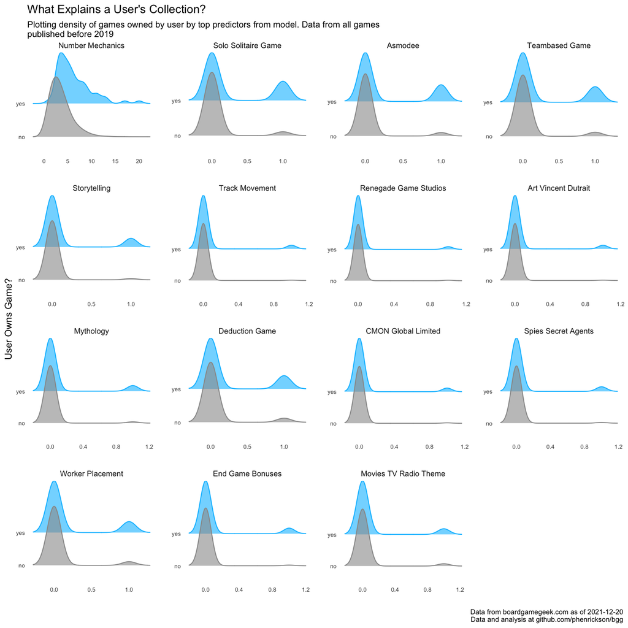

Binary predictors can be difficult to see with this visualization, so we can also directly examine the percentage of games in a user’s collection with a predictor vs the percentage of all games with that predictor.

| username | Feature | % of Games with Feature In_Collection | % of Games with Feature All_Games | Ratio |
| --- | --- | --- | --- | --- |
| Zabby | Track Movement | 6.3% | 0.6% | 10.2 |
| Zabby | Hidden Roles | 6.3% | 0.7% | 9.2 |
| Zabby | Communication Limits | 7.9% | 0.9% | 8.4 |
| Zabby | CMON Global Limited | 6.3% | 0.8% | 8.1 |
| Zabby | End Game Bonuses | 9.5% | 1.2% | 7.7 |
| Zabby | Storytelling | 14.3% | 2.1% | 6.7 |
| Zabby | Spies Secret Agents | 7.9% | 1.3% | 6.2 |
| Zabby | Renegade Game Studios | 4.8% | 0.9% | 5.5 |
| Zabby | Solo Solitaire Game | 28.6% | 5.8% | 5.0 |
| Zabby | Asmodee | 25.4% | 5.2% | 4.8 |
| Zabby | Mafia | 3.2% | 0.7% | 4.6 |
| Zabby | Line Drawing | 3.2% | 0.7% | 4.4 |
| Zabby | Mythology | 9.5% | 2.2% | 4.3 |
| Zabby | Environmental | 4.8% | 1.1% | 4.3 |
| Zabby | Teambased Game | 23.8% | 6.2% | 3.8 |
| Zabby | Deduction Game | 20.6% | 6.3% | 3.3 |
| Zabby | Worker Placement | 17.5% | 5.9% | 3.0 |
| Zabby | Fantasy Flight Games | 7.9% | 2.6% | 3.0 |
| Zabby | Adventure | 19.0% | 6.6% | 2.9 |
| Zabby | Pegasus Spiele | 12.7% | 4.7% | 2.7 |
| Zabby | Bluffing | 17.5% | 6.7% | 2.6 |
| Zabby | Movies TV Radio Theme | 9.5% | 3.9% | 2.4 |
| Zabby | Take That | 14.3% | 6.6% | 2.2 |
| Zabby | Horror | 1.6% | 4.0% | 0.4 |
| Zabby | Point To Point Movement | 1.6% | 5.2% | 0.3 |

# 3 Assess Model’s Performance on Training Set

Before predicting games in upcoming years, we can examine how well the model did and what games it liked in the training set. In this case, we used resampling techniques (cross validation) to ensure that the model had not seen a game before making its predictions.

## 3.1 Separation Plot

An easy way to examine the performance of classification model is to view a separation plot. We plot the predicted probabilities from the model for every game (from resampling) from lowest to highest. We then overlay a blue line for any game that the user does own. A good classifier is one that is able to *separate* the blue (games owned by the user) from the white (games not owned by the user), with most of the blue occurring at the highest probabilities (right side of the chart).

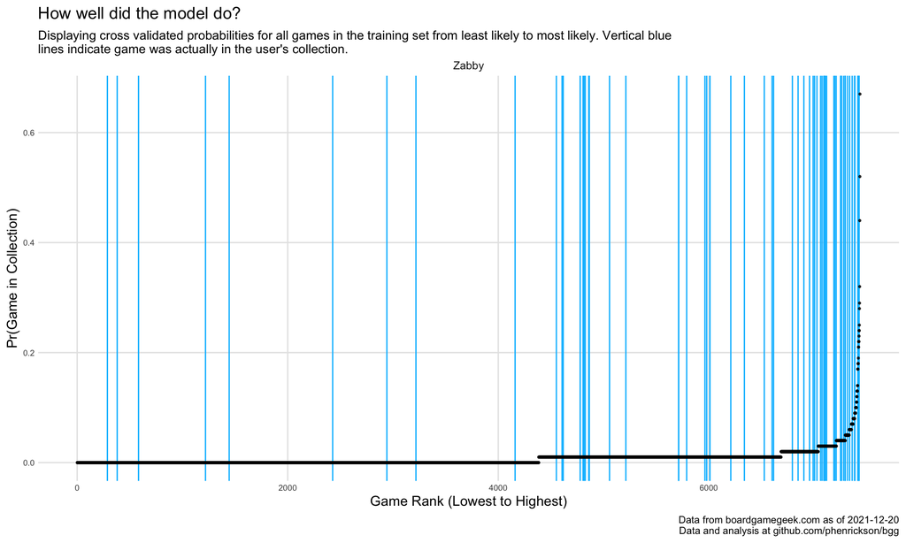

## 3.2 Top Games for **Zabby** from Training Set

We can display this information in table form, displaying the 100 games with the highest probability of ownership, adding a blue line when the user does own the game.

| username | yearpublished | game_id | name | pred_played | pred_own | actual_played | actual_own |
| --- | --- | --- | --- | --- | --- | --- | --- |
| Zabby | 2016 | 198454 | When I Dream | 0.92 | 0.67 | 0 | 0 |
| Zabby | 2017 | 188920 | This War of Mine: The Board Game | 0.59 | 0.52 | 0 | 0 |
| Zabby | 2019 | 283863 | The Magnificent | 0.75 | 0.44 | 0 | 0 |
| Zabby | 2014 | 156129 | Deception: Murder in Hong Kong | 0.95 | 0.32 | 1 | 0 |
| Zabby | 2018 | 253106 | Narcos: The Board Game | 0.15 | 0.29 | 0 | 0 |
| Zabby | 2019 | 257066 | Sierra West | 0.08 | 0.28 | 0 | 0 |
| Zabby | 2019 | 251247 | Barrage | 0.19 | 0.25 | 0 | 0 |
| Zabby | 2017 | 174430 | Gloomhaven | 0.93 | 0.24 | 1 | 1 |
| Zabby | 2015 | 163967 | Tiny Epic Galaxies | 0.10 | 0.24 | 0 | 0 |
| Zabby | 2015 | 178900 | Codenames | 0.47 | 0.23 | 0 | 0 |
| Zabby | 2010 | 73439 | Troyes | 0.23 | 0.22 | 0 | 0 |
| Zabby | 2019 | 264220 | Tainted Grail: The Fall of Avalon | 0.61 | 0.22 | 1 | 0 |
| Zabby | 2018 | 242639 | Treasure Island | 0.15 | 0.22 | 1 | 1 |
| Zabby | 2018 | 222509 | Lords of Hellas | 0.20 | 0.21 | 1 | 0 |
| Zabby | 2012 | 121921 | Robinson Crusoe: Adventures on the Cursed Island | 0.15 | 0.21 | 1 | 0 |
| Zabby | 2019 | 276025 | Maracaibo | 0.44 | 0.19 | 0 | 0 |
| Zabby | 2019 | 270971 | Era: Medieval Age | 0.57 | 0.18 | 0 | 0 |
| Zabby | 2018 | 231327 | The Grizzled: Armistice Edition | 0.18 | 0.18 | 0 | 0 |
| Zabby | 2014 | 146652 | Legendary Encounters: An Alien Deck Building Game | 0.16 | 0.18 | 0 | 0 |
| Zabby | 2008 | 37111 | Battlestar Galactica: The Board Game | 0.46 | 0.17 | 0 | 0 |
| Zabby | 2013 | 140620 | Lewis & Clark: The Expedition | 0.31 | 0.17 | 1 | 1 |
| Zabby | 2018 | 205896 | Rising Sun | 0.84 | 0.17 | 1 | 1 |
| Zabby | 2012 | 128882 | The Resistance: Avalon | 0.25 | 0.14 | 0 | 0 |
| Zabby | 2016 | 156858 | Black Orchestra | 0.24 | 0.14 | 0 | 0 |
| Zabby | 2010 | 73171 | Earth Reborn | 0.29 | 0.13 | 0 | 0 |
| Zabby | 2007 | 31481 | Galaxy Trucker | 0.07 | 0.13 | 0 | 0 |
| Zabby | 2005 | 15062 | Shadows over Camelot | 0.46 | 0.13 | 0 | 0 |
| Zabby | 2018 | 225167 | Human Punishment: Social Deduction 2.0 | 0.11 | 0.13 | 0 | 0 |
| Zabby | 2016 | 204837 | Game of Thrones: The Iron Throne | 0.10 | 0.13 | 0 | 0 |
| Zabby | 2018 | 205477 | Vengeance | 0.22 | 0.12 | 0 | 0 |

[output cut: 70 more lines]

We can also more formally assess how well the model did in resampling by looking at the area under the receiver operating characteristic. A perfect model would receive a score of 1, while a model that cannot predict the outcome will default to a score of 0.5. The extent to which something is a *good* score depends on the setting, but generally anything in the .8 to .9 range is very good while the .7 to .8 range is perfectly acceptable.

| username | outcome_type | .metric | .estimator | .estimate |
| --- | --- | --- | --- | --- |
| Zabby | own | roc_auc | binary | 0.818 |
| Zabby | played | roc_auc | binary | 0.869 |

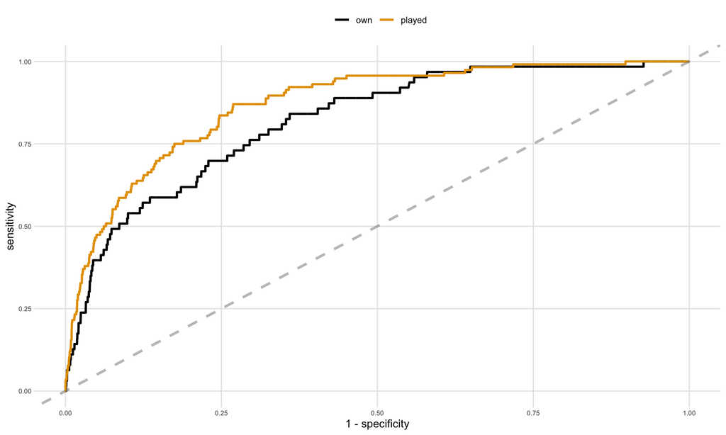

Another way to think about the model performance is to view its lift, or its ability to detect the positive outcomes over that of a null model. High lift indicates the model can much more quickly find all of the positive outcomes (in this case, games owned or played by the user), while a model with no lift is no better than random guessing.

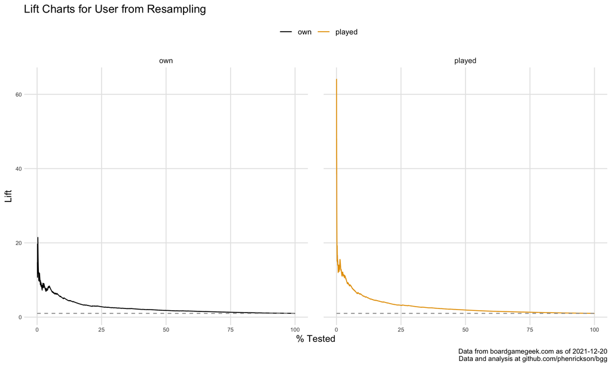

## 3.3 Most and Least Likely Games

What games does the model think Zabby is **most likely to own** that are **not** in their collection?

| username | yearpublished | game_id | name | pred_own | actual_own |
| --- | --- | --- | --- | --- | --- |
| Zabby | 2016 | 198454 | When I Dream | 0.67 | 0 |
| Zabby | 2017 | 188920 | This War of Mine: The Board Game | 0.52 | 0 |
| Zabby | 2019 | 283863 | The Magnificent | 0.44 | 0 |
| Zabby | 2014 | 156129 | Deception: Murder in Hong Kong | 0.32 | 0 |
| Zabby | 2018 | 253106 | Narcos: The Board Game | 0.29 | 0 |

What games does the model think Zabby is **least likely to own** that **are** in their collection?

| username | yearpublished | game_id | name | pred_own | actual_own |
| --- | --- | --- | --- | --- | --- |
| Zabby | 2015 | 153999 | ...and then, we held hands. | 0 | 1 |
| Zabby | 2006 | 22245 | Royal Visit | 0 | 1 |
| Zabby | 2014 | 160477 | Onitama | 0 | 1 |
| Zabby | 2018 | 212402 | The Grimm Forest | 0 | 1 |
| Zabby | 2014 | 154906 | Isle of Trains | 0 | 1 |

## 3.4 Top Games by Year

Top 25 games most likely to be owned by the user in each year, highlighting in blue the games that the user has owned/played.

| rank | 2011 | 2012 | 2013 | 2014 | 2015 | 2016 | 2017 | 2018 | 2019 |
| --- | --- | --- | --- | --- | --- | --- | --- | --- | --- |
| 1 | Mage Knight Board Game | Robinson Crusoe: Adventures on the Cursed Island | Lewis & Clark: The Expedition | Deception: Murder in Hong Kong | Tiny Epic Galaxies | When I Dream | This War of Mine: The Board Game | Narcos: The Board Game | The Magnificent |
| 2 | Dark Moon | The Resistance: Avalon | Pathfinder Adventure Card Game: Rise of the Runelords – Base Set | Legendary Encounters: An Alien Deck Building Game | Codenames | Black Orchestra | Gloomhaven | Treasure Island | Sierra West |
| 3 | Discworld: Ankh-Morpork | The Last Banquet | Prosperity | Camel Up | Burgle Bros. | Game of Thrones: The Iron Throne | Codenames: Duet | Lords of Hellas | Barrage |
| 4 | Letters from Whitechapel | Mice and Mystics | Room 25 | Witness | The Pursuit of Happiness | Terraforming Mars | Breaking Bad: The Board Game | The Grizzled: Armistice Edition | Tainted Grail: The Fall of Avalon |
| 5 | Takenoko | Descent: Journeys in the Dark (Second Edition) | LEADERS: The Combined Strategy Game | Spyfall | Specter Ops | Sherlock Holmes Consulting Detective: Jack the Ripper & West End Adventures | Fallout | Rising Sun | Maracaibo |
| 6 | Tragedy Looper | Il Vecchio | BANG! The Dice Game | Five Tribes | Argonauts | Mansions of Madness: Second Edition | The Godfather: Corleone's Empire | Human Punishment: Social Deduction 2.0 | Era: Medieval Age |
| 7 | Flash Point: Fire Rescue | CO₂ | Tomorrow | Arcadia Quest | The Grizzled | Exceed Fighting System | Fate of the Elder Gods | Vengeance | Spire's End |
| 8 | Santiago de Cuba | Dixit: Journey | Gravwell: Escape from the 9th Dimension | Patchwork | Kingdom Death: Monster | Flamme Rouge | Photosynthesis | Teotihuacan: City of Gods | Hellenica: Story of Greece |
| 9 | Rory's Story Cubes: Voyages | Space Cadets | The Hobbit: An Unexpected Journey | Sons of Anarchy: Men of Mayhem | One Night Revolution | Hit Z Road | Fog of Love | Newton | De Vulgari Eloquentia: Deluxe Edition |
| 10 | Dixit: Odyssey | Agents of SMERSH | Concept | Abyss | T.I.M.E Stories | Martians: A Story of Civilization | Heaven & Ale | The World of SMOG: Rise of Moloch | God of War: The Card Game |
| 11 | Mundus Novus | Starship Merchants | Forbidden Desert | Alchemists | Sylvion | The Oregon Trail Card Game | Whitehall Mystery | The City of Kings | Tiny Towns |
| 12 | Dungeons & Dragons: The Legend of Drizzt Board Game | Serenissima (Second Edition) | Agent Hunter | Stay Away! | Thunderbirds | Clank!: A Deck-Building Adventure | Betrayal at Baldur's Gate | Luxor | PARKS |
| 13 | Gears of War: The Board Game | Winter Tales | Legacy: The Testament of Duke de Crecy | [redacted] | Warhammer Quest: The Adventure Card Game | Apotheca | First Martians: Adventures on the Red Planet | Detective: A Modern Crime Board Game | Paladins of the West Kingdom |
| 14 | Shitenno | Shadows over Camelot: The Card Game | Duel of Ages II | Don't Mess with Cthulhu | Mafia de Cuba | Timebomb | Mythic Battles: Pantheon | Everdell | It's a Wonderful World |
| 15 | Ninja: Legend of the Scorpion Clan | Archipelago | Race! Formula 90 | Templar Intrigue | Mysterium | The Networks | Pendragon: The Fall of Roman Britain | Don't Mess with Cthulhu Deluxe | Pax Pamir: Second Edition |
| 16 | TSCHAK! | Tokaido | Impulse | Deus | Aye, Dark Overlord! The Green Box | Bloodborne: The Card Game | Gaia Project | Kero | Sabotage |
| 17 | Trajan | Kemet | Ladies & Gentlemen | DungeonQuest Revised Edition | Grimslingers | Smash Up: It's Your Fault! | Ex Libris | Holding On: The Troubled Life of Billy Kerr | Yukon Airways |
| 18 | 011 | In Magnificent Style: Pickett's Charge at Gettysburg | A Study in Emerald | Dragon's Hoard | Raptor | Inis | Escape the Dark Castle | Big Trouble in Little China: The Game | Middara: Unintentional Malum – Act 1 |
| 19 | Eclipse | Star Trek Deck Building Game: The Next Generation – Next Phase | The Ravens of Thri Sahashri | Ultimate Werewolf: Deluxe Edition | Bottom of the 9th | Days of Ire: Budapest 1956 | The 7th Continent | Railroad Ink: Deep Blue Edition | Clank!: Legacy – Acquisitions Incorporated |
| 20 | Mansions of Madness | Tzolk'in: The Mayan Calendar | City of Remnants | Secret Moon | I, Spy | Yokohama | The Quest for El Dorado | Warhammer Quest: Blackstone Fortress | Comanauts |
| 21 | A Few Acres of Snow | Andean Abyss | Theseus: The Dark Orbit | Three Kingdoms Redux | Blood Rage | Warhammer Quest: Silver Tower | Azul | Star Wars: Legion | Atlantis Rising (Second Edition) |
| 22 | Sekigahara: The Unification of Japan | Wiz-War (Eighth Edition) | Tash-Kalar: Arena of Legends | Ultimate Werewolf | Elysium | Agricola (Revised Edition) | Wendake | Choose Your Own Adventure: House of Danger | UNDO: Cherry Blossom Festival |
| 23 | Space Infantry | Seasons | Infamy | Bucket of Doom | The King Is Dead | Codenames: Pictures | Sherlock Holmes Consulting Detective: Carlton House & Queen's Park | Battlestar Galactica: Starship Battles – Starter Set | Crusader Kings |
| 24 | Steam Torpedo: First Contact | Divinare | Firefly: The Game | Spurs: A Tale in the Old West | Valley of the Kings: Afterlife | Codenames: Deep Undercover | Twilight Imperium: Fourth Edition | Underwater Cities | Ragusa |
| 25 | Omen: A Reign of War | Love Letter | Corto | Dead of Winter: A Crossroads Game | 504 | Kreus | Legacy of Dragonholt | Solenia | The King's Dilemma |

## 3.5 Interactive Predictions from Resampling

Interactive table for predictions from resampling.

|  | username | yearpublished | rank | game_id | name | pred_played | pred_own | actual_played | actual_own |
| --- | --- | --- | --- | --- | --- | --- | --- | --- | --- |
| 1 | Zabby | 1900 | 2493 | 2785 | Game of Goose | 0 | 0.01 | 0 | 0 |
| 2 | Zabby | 1900 | 3064 | 5546 | Marbles | 0 | 0 | 0 | 0 |
| 3 | Zabby | 1900 | 3067 | 11901 | Tic-Tac-Toe | 0 | 0 | 0 | 0 |
| 4 | Zabby | 1900 | 3102 | 188 | Go | 0 | 0 | 0 | 0 |
| 5 | Zabby | 1900 | 3192 | 171 | Chess | 0 | 0 | 0 | 0 |
| 6 | Zabby | 1900 | 3200 | 2065 | Shogi | 0 | 0 | 0 | 0 |
| 7 | Zabby | 1900 | 3202 | 2393 | Xiangqi | 0 | 0 | 0 | 0 |
| 8 | Zabby | 1900 | 3357 | 26952 | International Checkers | 0 | 0 | 0 | 0 |
| 9 | Zabby | 1900 | 3381 | 1602 | The Royal Game of Ur | 0 | 0 | 0 | 0 |
| 10 | Zabby | 1900 | 3382 | 2083 | Checkers | 0 | 0 | 0 | 0 |

[output cut: 7426 more lines]

# 4 Validating the Model on 2020

How well did a model trained on a user’s collection through 2019 perform in predicting games for the user from 2020?

| username | outcome_type | yearpublished | .metric | .estimator | .estimate |
| --- | --- | --- | --- | --- | --- |
| Zabby | own | 2020 | roc_auc | binary | 0.794 |
| Zabby | played | 2020 | roc_auc | binary | 0.816 |

Table of top 25 games from 2020, highlighting games that the user owns.

| username | yearpublished | game_id | name | pred_own | pred_played | actual_own | actual_played |
| --- | --- | --- | --- | --- | --- | --- | --- |
| Zabby | 2020 | 295646 | Spyfest | 0.27 | 0.19 | 0 | 0 |
| Zabby | 2020 | 291457 | Gloomhaven: Jaws of the Lion | 0.24 | 0.71 | 0 | 0 |
| Zabby | 2020 | 253506 | Versailles 1919 | 0.14 | 0.07 | 0 | 0 |
| Zabby | 2020 | 301880 | Raiders of Scythia | 0.14 | 0.50 | 0 | 0 |
| Zabby | 2020 | 184267 | On Mars | 0.13 | 0.42 | 1 | 1 |
| Zabby | 2020 | 292333 | Cowboys II: Cowboys & Indians Edition | 0.11 | 0.60 | 0 | 0 |
| Zabby | 2020 | 315954 | Hunt A Killer: Death at the Dive Bar | 0.11 | 0.42 | 0 | 0 |
| Zabby | 2020 | 279537 | The Search for Planet X | 0.10 | 0.13 | 0 | 0 |
| Zabby | 2020 | 296151 | Viscounts of the West Kingdom | 0.10 | 0.19 | 1 | 1 |
| Zabby | 2020 | 316554 | Dune: Imperium | 0.10 | 0.14 | 0 | 1 |
| Zabby | 2020 | 301767 | Mysterium Park | 0.09 | 0.40 | 1 | 1 |
| Zabby | 2020 | 296237 | Warp's Edge | 0.08 | 0.20 | 0 | 0 |
| Zabby | 2020 | 302723 | Forgotten Waters | 0.08 | 0.22 | 0 | 1 |
| Zabby | 2020 | 256317 | Guild Master | 0.07 | 0.12 | 0 | 0 |
| Zabby | 2020 | 300322 | Hallertau | 0.07 | 0.26 | 0 | 0 |
| Zabby | 2020 | 305498 | Tomorrow Dies Today | 0.07 | 0.09 | 0 | 0 |
| Zabby | 2020 | 306040 | Merv: The Heart of the Silk Road | 0.07 | 0.13 | 0 | 0 |
| Zabby | 2020 | 325555 | Cantaloop: Book 1 – Breaking into Prison | 0.07 | 0.13 | 0 | 0 |
| Zabby | 2020 | 332782 | Cantaloop: Prequel | 0.07 | 0.10 | 0 | 0 |
| Zabby | 2020 | 227224 | The Red Cathedral | 0.06 | 0.09 | 0 | 0 |
| Zabby | 2020 | 262274 | D6: Dungeons, Dudes, Dames, Danger, Dice and Dragons! | 0.06 | 0.14 | 0 | 0 |
| Zabby | 2020 | 302425 | Unlock!: Mythic Adventures | 0.06 | 0.21 | 0 | 0 |
| Zabby | 2020 | 306481 | Tawantinsuyu: The Inca Empire | 0.06 | 0.21 | 0 | 0 |
| Zabby | 2020 | 308765 | Praga Caput Regni | 0.06 | 0.04 | 0 | 0 |
| Zabby | 2020 | 252153 | Tang Garden | 0.05 | 0.11 | 1 | 1 |

# 5 Predicting Upcoming Games (2020 and On) for **Zabby**

Examine the top games for the test set.

| username | yearpublished | game_id | name | rank | own | played |
| --- | --- | --- | --- | --- | --- | --- |
| Zabby | 2020 | 295646 | Spyfest | 1 | 0.27 | 0.19 |
| Zabby | 2020 | 291457 | Gloomhaven: Jaws of the Lion | 2 | 0.24 | 0.71 |
| Zabby | 2020 | 301880 | Raiders of Scythia | 3 | 0.14 | 0.50 |
| Zabby | 2020 | 253506 | Versailles 1919 | 4 | 0.14 | 0.07 |
| Zabby | 2020 | 184267 | On Mars | 5 | 0.13 | 0.42 |
| Zabby | 2020 | 315954 | Hunt A Killer: Death at the Dive Bar | 6 | 0.11 | 0.42 |
| Zabby | 2020 | 292333 | Cowboys II: Cowboys & Indians Edition | 7 | 0.11 | 0.60 |
| Zabby | 2020 | 279537 | The Search for Planet X | 8 | 0.10 | 0.13 |
| Zabby | 2020 | 316554 | Dune: Imperium | 9 | 0.10 | 0.14 |
| Zabby | 2020 | 296151 | Viscounts of the West Kingdom | 10 | 0.10 | 0.19 |
| Zabby | 2020 | 301767 | Mysterium Park | 11 | 0.09 | 0.40 |
| Zabby | 2020 | 296237 | Warp's Edge | 12 | 0.08 | 0.20 |
| Zabby | 2020 | 302723 | Forgotten Waters | 13 | 0.08 | 0.22 |
| Zabby | 2020 | 256317 | Guild Master | 14 | 0.07 | 0.12 |
| Zabby | 2020 | 305498 | Tomorrow Dies Today | 15 | 0.07 | 0.09 |
| Zabby | 2020 | 300322 | Hallertau | 16 | 0.07 | 0.26 |
| Zabby | 2020 | 325555 | Cantaloop: Book 1 – Breaking into Prison | 17 | 0.07 | 0.13 |
| Zabby | 2020 | 332782 | Cantaloop: Prequel | 18 | 0.07 | 0.10 |
| Zabby | 2020 | 306040 | Merv: The Heart of the Silk Road | 19 | 0.07 | 0.13 |
| Zabby | 2020 | 227224 | The Red Cathedral | 20 | 0.06 | 0.09 |
| Zabby | 2020 | 306481 | Tawantinsuyu: The Inca Empire | 21 | 0.06 | 0.21 |
| Zabby | 2020 | 262274 | D6: Dungeons, Dudes, Dames, Danger, Dice and Dragons! | 22 | 0.06 | 0.14 |
| Zabby | 2020 | 302425 | Unlock!: Mythic Adventures | 23 | 0.06 | 0.21 |
| Zabby | 2020 | 308765 | Praga Caput Regni | 24 | 0.06 | 0.04 |
| Zabby | 2020 | 293531 | Detective: A Modern Crime Board Game – Season One | 25 | 0.05 | 0.23 |
| Zabby | 2021 | 298102 | Roll Camera!: The Filmmaking Board Game | 1 | 0.17 | 0.48 |
| Zabby | 2021 | 338834 | MicroMacro: Crime City – Full House | 2 | 0.13 | 0.29 |
| Zabby | 2021 | 285967 | Ankh: Gods of Egypt | 3 | 0.13 | 0.50 |
| Zabby | 2021 | 313262 | Shamans | 4 | 0.12 | 0.13 |
| Zabby | 2021 | 316287 | Quest | 5 | 0.11 | 0.27 |
| Zabby | 2021 | 299255 | Vienna Connection | 6 | 0.11 | 0.53 |
| Zabby | 2021 | 310873 | Carnegie | 7 | 0.10 | 0.38 |
| Zabby | 2021 | 251661 | Oathsworn: Into the Deepwood | 8 | 0.10 | 0.36 |
| Zabby | 2021 | 343905 | Boonlake | 9 | 0.10 | 0.10 |
| Zabby | 2021 | 273330 | Bloodborne: The Board Game | 10 | 0.10 | 0.27 |
| Zabby | 2021 | 340909 | Gloomholdin' | 11 | 0.09 | 0.25 |
| Zabby | 2021 | 249277 | Brazil: Imperial | 12 | 0.09 | 0.25 |
| Zabby | 2021 | 336382 | Marvel United: X-Men | 13 | 0.08 | 0.15 |
| Zabby | 2021 | 340466 | Unfathomable | 14 | 0.08 | 0.24 |
| Zabby | 2021 | 279087 | Zerywia | 15 | 0.08 | 0.23 |
| Zabby | 2021 | 299566 | Batman: The Animated Series Adventures – Shadow of the Bat | 16 | 0.08 | 0.07 |
| Zabby | 2021 | 304783 | Hadrian's Wall | 17 | 0.08 | 0.27 |
| Zabby | 2021 | 312904 | Conan the Cimmerian: The Tower of the Elephant | 18 | 0.07 | 0.14 |
| Zabby | 2021 | 342942 | Ark Nova | 19 | 0.07 | 0.11 |
| Zabby | 2021 | 340677 | Bad Company | 20 | 0.07 | 0.07 |
| Zabby | 2021 | 341169 | Great Western Trail (Second Edition) | 21 | 0.07 | 0.08 |
| Zabby | 2021 | 319263 | One Card Dungeon | 22 | 0.06 | 0.13 |
| Zabby | 2021 | 313730 | Harsh Shadows | 23 | 0.06 | 0.09 |
| Zabby | 2021 | 260789 | Assassin's Creed: Brotherhood of Venice | 24 | 0.06 | 0.14 |
| Zabby | 2021 | 316786 | Tabannusi: Builders of Ur | 25 | 0.06 | 0.07 |
| Zabby | 2022 | 317511 | Tindaya | 1 | 0.22 | 0.36 |
| Zabby | 2022 | 322524 | Bardsung | 2 | 0.15 | 0.39 |
| Zabby | 2022 | 283137 | Human Punishment: The Beginning | 3 | 0.14 | 0.44 |
| Zabby | 2022 | 295770 | Frosthaven | 4 | 0.11 | 0.41 |
| Zabby | 2022 | 331106 | The Witcher: Old World | 5 | 0.11 | 0.33 |
| Zabby | 2022 | 273814 | Deliverance | 6 | 0.09 | 0.37 |
| Zabby | 2022 | 311823 | Nova Aetas Renaissance | 7 | 0.07 | 0.13 |
| Zabby | 2022 | 320718 | Hidden Leaders | 8 | 0.07 | 0.12 |
| Zabby | 2022 | 319807 | Shogun no Katana | 9 | 0.06 | 0.09 |
| Zabby | 2022 | 331401 | Dog Park | 10 | 0.06 | 0.06 |
| Zabby | 2022 | 280726 | Legacies | 11 | 0.06 | 0.09 |
| Zabby | 2022 | 274471 | Malhya: Lands of Legends | 12 | 0.05 | 0.10 |
| Zabby | 2022 | 305096 | Endless Winter: Paleoamericans | 13 | 0.05 | 0.06 |
| Zabby | 2022 | 305462 | The Age of Atlantis | 14 | 0.05 | 0.14 |
| Zabby | 2022 | 271601 | Feed the Kraken | 15 | 0.05 | 0.11 |
| Zabby | 2022 | 304051 | Creature Comforts | 16 | 0.05 | 0.07 |
| Zabby | 2022 | 340325 | Vagrantsong | 17 | 0.05 | 0.09 |
| Zabby | 2022 | 317321 | Darkest Dungeon: The Board Game | 18 | 0.04 | 0.12 |
| Zabby | 2022 | 324090 | Scarface 1920 | 19 | 0.04 | 0.05 |
| Zabby | 2022 | 240980 | Blood on the Clocktower | 20 | 0.03 | 0.07 |
| Zabby | 2022 | 295374 | Long Shot: The Dice Game | 21 | 0.03 | 0.04 |
| Zabby | 2022 | 334065 | Verdant | 22 | 0.03 | 0.07 |
| Zabby | 2022 | 299106 | Fractal: Beyond the Void | 23 | 0.03 | 0.08 |
| Zabby | 2022 | 335427 | Wild: Serengeti | 24 | 0.03 | 0.04 |
| Zabby | 2022 | 277025 | Vampire: The Masquerade – CHAPTERS | 25 | 0.03 | 0.08 |

## 5.1 Interactive Table for Upcoming Games 2020 and On

|  | username | yearpublished | game_id | name | rank | own | played |
| --- | --- | --- | --- | --- | --- | --- | --- |
| 1 | Zabby | 2020 | 295646 | Spyfest | 1 | 0.27 | 0.19 |
| 2 | Zabby | 2020 | 291457 | Gloomhaven: Jaws of the Lion | 2 | 0.24 | 0.71 |
| 3 | Zabby | 2022 | 317511 | Tindaya | 3 | 0.22 | 0.36 |
| 4 | Zabby | 2021 | 298102 | Roll Camera!: The Filmmaking Board Game | 4 | 0.17 | 0.48 |
| 5 | Zabby | 2022 | 322524 | Bardsung | 5 | 0.15 | 0.39 |
| 6 | Zabby | 2022 | 283137 | Human Punishment: The Beginning | 6 | 0.14 | 0.44 |
| 7 | Zabby | 2020 | 301880 | Raiders of Scythia | 7 | 0.14 | 0.5 |
| 8 | Zabby | 2020 | 253506 | Versailles 1919 | 8 | 0.14 | 0.07 |
| 9 | Zabby | 2021 | 338834 | MicroMacro: Crime City – Full House | 9 | 0.13 | 0.29 |
| 10 | Zabby | 2020 | 184267 | On Mars | 10 | 0.13 | 0.42 |

[output cut: 1627 more lines]